# Projekt 3 - Hőmérséklet folytonos ábrázolása

Papa és mama egyre jobban meg vannak elégedve a probléma megoldó képességeddel és látják milyen szépen elkészíted amit kérnek. Sajnos be kell látniuk, hogy bennük van a hiba, hogy nem gondolják át eléggé mit is szeretnének látni. Így most egy újabb kéréssel állnak eléd, hiszen belátták, hogy az jó, ha látjuk milyen volt a hőmérséklet valamikor, de azt nem látják, hogy pont most milyen az előző pillanatokhoz képest.

Megkérnek, hogy készíts egy olyan hőmérsékletmérőt, ami a kiplottolja az utolsó 20 mérést az idő függvényében, azaz folytonosan követhetik, hogy változik a hőmérséklet az adott helységben.

## Mit fogsz készíteni?

Egy DS18b20 szenzorból (és ha kell egy ellenállásból) álló áramkört készítünk, amiből másodpercenként kiolvassuk a hőmérsékletet és azt egy grafikonon ábrázoljuk, ami folytonosan frissíti magát. Egy változtatható paraméterrel beállítjuk, hogy az utolsó 20 mérést ábrázolja a grafikon a mérés pillanatának függvényében.

## Mit tanulsz meg?

A hőmérő szenzor elkészítésével a következőket tanulod meg:

- Hogyan futtas terminál parancsokat Pythonból.
- Hogyan keress fájlokat és mappákat az operációs rendszeredben Pythonból a `glob` csomaggal.
- Hogyan olvassuk ki egy szöveges fájl tartalmát az `open` parancs használatával.
- Hogyan nyerjünk ki hasznos információt egy szöveges fájlból string parancsokat használva.
- Hogyan kezeljük a dátum formátumokat a `datetime` csomag segítségével.
- Hogyan frissítsük a plottolásunkat folyamatosan a `matplotlib` csomag segítségével.

## A projekt részletekre bontása

- Elkészíteni az áramkört.
- Előkészíteni a kommunikációt a thermisztorral (`modprobe` parancsok futtatása).
- Definiálni a hőmérsékletet tartalmazó fájl lokációját.
- Kiolvasni a fájl tartalmát az `open` parancs segítségével.
- Definiálni egy függvényt ami a fájlból kinyeri a hőmérsékletet és a kiolvasás időpontját.
- Definiálni egy függvényt, ami feltölti az idő és hőmérséklet listákat adatokkal és gondoskodik arról, hogy bennük mindig 20 mérés legyen.
- Előkészíteni a plottolást, cím, tengely nevek, háló stb.
- Másodpercenként megismételni egy végtelen ciklusban az új elemek ábrázolását.
- Frissíteni a tengelyek paramétereit is, hogy sose menyjenek ki a mért értékek a határértékekből.

## Áramköri elemek listája

a) [Raspberry PI](https://malnapc.hu/yis/raspberry-pi/rpi-panelek)

b) DS18b20 szenzor: [itt vásárolhatsz](https://www.tme.eu/hu/details/ds18b20+/homerseklet-jelatalakitok/maxim-integrated/)

c) [Jumper wires female/male](https://www.ret.hu/shop/product/e-call/jumper-vezetek-szet_53-22-63)

d) Ellenállás: [itt vásárolhatsz](https://www.tme.eu/hu/katalog/metal-film-tht-ellenallasok_112313/?s_order=desc&search=ellenallas&s_field=1000011)

## A kapcsolási rajz

[figure not shown]

A fenti ábrához hasonlóan kapcsoljuk össze az áramköri elemeket és a Raspberry Pi-t. Az áramkör részletes összekötési magyarázata a Thermisztorok című bevezető leírásban található.

1) Kössük össze a Raspberry Pi egyik földelését a szenzor GND jelű lábával (fekete drót).

2) A szenzor Vcc és Signal lábait kössük össze egy 4.7 kOhmos ellenállással (ez a lépés nem szükséges, ha ez az ellenállás már alapból be van építve).

3) A szenzor Signal lábát (középső láb) kössük össze a Raspberryn a *GPIO04*-es tüskével (kék drót).

4) A szenzor Vcc lábát kössük a Raspberry 3.3 V-os táp tüskéjére (piros drót).

## A kód

Nyissunk meg egy új python fájlt és mentsük el pl. `ds18b20_continuous_plot.py` név alatt. A `gpiozero` csomagnak nincs beépített objektuma ami általánosan a thermisztorokkat tudná kezelni, így minden egyes thermisztorhoz nekünk kell megoldani a szoftveres kommunikációt az adott eszközzel.

### A DS18b20 hőmérséklet fájljának előkészítése

Miután elkészítettük az áramkört, meg kell írnunk a kódot ami utasítja a Raspberry Pi-t, a hőmérséklet kiolvasására.

Mint tudjuk a hőmérséklet értékeket a Raspberry egy kernel parancs elindításával fogja majd a *w1_slave* nevű fájlban tárolni. Az előző projektekben már megtanultuk, hogyan olvashatjuk ki a hőmérsékletet a fájl tartalmából és rendelhetjük hozzá a kiolvasás időpontját. Most azt fogjuk újra hasznosítani egy kis módosítással.

Hasznosítsuk újra az előző projekt kódjának számunkra megfelelő részét, másoljuk ki az új fájlunkba. Tesztelésképp nyomtassuk ki a képernyőre a mért hőmérsékleteket és a hozzájuk tartozó időpillanatokat.

`ds18b20_continuous_plot.py`:

```python
import os
import glob
import time
import datetime as dt

os.system('modprobe w1-gpio')
os.system('modprobe w1-therm')

base_dir = '/sys/bus/w1/devices/'
device_folder = glob.glob(base_dir + '28*')[0]
device_file = device_folder + '/w1_slave'

def read_temp_raw(file_name):
    f = open(file_name, 'r')
    lines = f.readlines()
    f.close()
    return lines

def read_temp(file_name):
    lines = read_temp_raw(file_name)
    # rögzítjuk az aktuális időpontot
    now = dt.datetime.today().strftime('%Y-%m-%d %H:%M:%S')
    while lines[0].strip()[-3:] != 'YES':
        time.sleep(0.2)
        lines = read_temp_raw(file_name)
    equals_pos = lines[1].find('t=')
    if equals_pos != -1:
        temp_string = lines[1][equals_pos+2:]
        temp_c = float(temp_string) / 1000.0
        temp_f = temp_c * 9.0 / 5.0 + 32.0
        return temp_c, temp_f, now

while True:
	tc, tf, ts = read_temp(device_file)
    print(ts, tc, tf)
    time.sleep(1)
```

### Adatok előkészítése mentéshez

Az ábrázoláshoz két bemenő paraméterre van szükségünk, egy idő listára és egy hőmérséklet listára. Ezt a listát folytonosan frissítenünk is kell. Ezt egy `prepare_data(date, tc, dplot, tplot, maxlen=20)` függvénnyel tesszük meg, aminek a bemenő paraméterei:

- `date` az új mérési időpont, amit `string` típusban kell megadni,
- `tc` az újonnan mért hőmérséklet,
- `dplot` a lista ami tartalmazza azokat az időpillanatokat amit ábrázolni szeretnénk,
- `tplot` a lista ami tartalmazza azokat a hőmérsékleteket amit ábrázolni szeretnénk,
- `maxlen=20` pedig a fenti két listának a maximálisan megengedett hosszát mutatja. Evvel szabályozzuk, hogy az elmúlt hány mérést szeretnénk látni a grafikonon.

Első lépésként a `string` formátumú dátumot visszaalakítjuk `datetime` típusba, mert azt a `matplotlib.pyplot`, könnyen tud kezelni, `dd = dt.datetime.strptime(date, '%Y-%m-%d %H:%M:%S')`. Ezután mind az időlistához, mind a hőmérséklet listához, hozzáadjuk az újonnan mért elemeket. Majd le kell ellenőriznünk, hogy az így kapott lista nem hosszabb, mint az előre megszabott `maxlen` érték, `if len(dplot) > maxlen`. Ha hosszabb, akkor távolítsuk el a listának a legelső elemét `dplot.pop(0)`, így biztosítjuk, hogy a lista hossza nem lesz nagyobb mint az előre eltervezett méret.

```python
def prepare_data(date, tc, dplot, tplot, maxlen=20):
	dd = dt.datetime.strptime(date, '%Y-%m-%d %H:%M:%S')
    dplot.append(dd)
	tplot.append(tc)
	if len(dplot) > maxlen:
		dplot.pop(0)
		tplot.pop(0)
	return dplot, tplot
```

### A plottolás előkészítése

A plottolás folyamatos frissítéséhez első lépésben létre kell hozni egy ábrát, amit egy `while` ciklusban majd folytonosan frissítünk. Ehhez először létrehozunk tároló listákat, `dplot` és `tplot`, amikbe az időpontokat és hőmérsékleteket tároljuk. Hogy elő tudjuk készíteni a grafikont, feltöltjük ezeket a listákat egy tetszőleges elemmel. A `plt.ion()` bekapcsolja az interaktív plottolási üzemmódot, ami azt jelenti, hogy plottolás után visszakapjuk a konzolban a gépelés lehetőségét. Inicializálunk egy ábrát amihez jár egy grafikon is (axes), `figure, ax = plt.subplots(figsize=(8,6))`, és megmondjuk, hogy az ábra mérete mekkora legyen. A grafikonra plottoljuk a tároló listánkat, `line1, = ax.plot(dplot, tplot, 'o-')`, miközben azt is meghatározzuk, hogy köröket és vonalakat használjunk marker és vonaltípusként, `o-`. Majd ellátjuk az ábrát magyarázó elemekkel:

- `plt.title("Dynamic Plot of temperature",fontsize=25)` - címet ad az ábrának 25-ös betűmérettel.
- `plt.xlabel("Time",fontsize=18)` - megnevezést ad az *x* tengelynek 18-as betűmérettel.
- `plt.ylabel("Temperature (C)",fontsize=18)` - megnevezést ad az *y* tengelynek 18-as betűmérettel.
- `plt.grid(True)` - koordinátahálót tesz a grafikonra.

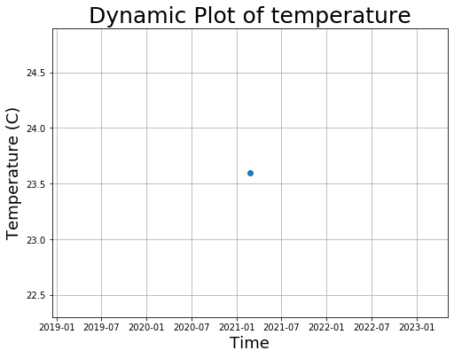

```python
import datetime as dt
import matplotlib.pyplot as plt

dplot = [dt.datetime.now()]   # idopont lista inicializalasa
tplot = [23.6]		 # homerseklet lista inicializalasa

plt.ion()           # interaktiv abrazolas bekapcsolasa

figure, ax = plt.subplots(figsize=(8,6))  # abra es grafikon inicializalasa
line1, = ax.plot(dplot, tplot, 'o-')     # a meres plottolasa a grafikonon

plt.title("Dynamic Plot of temperature",fontsize=25) # cim hozzaadas

plt.xlabel("Time",fontsize=18) # x tengely megnevezes
plt.ylabel("Temperature (C)",fontsize=18) # y tengely megnevezes
plt.grid(True) # koordinata halo hozzaadas
```

Láthatjuk, hogy egy pont jelenítődik meg a grafikon, hiszen csak egy mérési adatunk van eddig. Az *x* tengelyen a dátumok szépen jelennek meg, mivel a `datetime` típust használtuk.

Összerakva az eddigi elemeket elérkezünk a folytonos mérés ábrázolásához. A lenti kódban kommentekkel jeleztük az eddig nem tárgyalt kódrészleteket.

Elsőként egy változóban rögzítjük, `max_count`, hogy hány mérési adatot szeretnénk egyszerre megjeleníteni. Az ábra előkészítése után elindítjuk a végtelen `while` ciklust és feltöltjük benne a tároló listákat az új elemekkel. Az új adatokkal már frissíthetjük mind az *x* és az *y* tengely értékeit az ábrán, `line1.set_ydata(tplot)`. Mivel nem tudhatjuk, hogy a mért értékek mik lesznek és azok könnyen kimehetnek a legelőször ábrázolt érték tartományból, fontos, hogy az új méréseknek megfelelően frissítsük a tengelyeken a limitjeinket. Pl. az *x* tengelyen mindig a tároló lista legkisebb időpontjától a legnagyobbig terjedjen a tengelyen megjelenített dátum, `ax.set_xlim(min(dplot),max(dplot))`. Az *y* tengelyen viszont a hőmérséklet tároló legkisebb elemétől kicsit kisebb értéktől a legnagyobb elemétől kicsit nagyobb értékig terjedjen az ábrázolás, `ax.set_ylim(min(tplot)*0.99,max(tplot)*1.01)`, biztosítva, hogy az összes pontot látni fogjuk. Ezután élesíthetjük ezeket a változásokat, azaz megrajzoltathatjuk, `figure.canvas.draw()`. A folytonos ábrafrissítéseknél ajánlatos még a bármi jellegű GUI eseményeket is törölni, `figure.canvas.flush_events()`. És végül egy hasznos utasítással, `plt.gcf().autofmt_xdate()`, automatikusan esztétikusan és értelmezhetően jelenítjük meg az *x* tengely értékeit.

`ds18b20_continuous_plot.py`:

```python
import matplotlib.pyplot as plt
import os, glob, time
import datetime as dt


os.system('modprobe w1-gpio')
os.system('modprobe w1-therm')

base_dir = '/sys/bus/w1/devices/'
device_folder = glob.glob(base_dir + '28*')[0]
device_file = device_folder + '/w1_slave'


def read_temp_raw(file_name):
    f = open(file_name, 'r')
    lines = f.readlines()
    f.close()
    return lines

def read_temp(file_name):
    lines = read_temp_raw(file_name)
    now = dt.datetime.today().strftime('%Y-%m-%d %H:%M:%S')
    while lines[0].strip()[-3:] != 'YES':
        time.sleep(0.2)
        lines = read_temp_raw(file_name)
    equals_pos = lines[1].find('t=')
    if equals_pos != -1:
        temp_string = lines[1][equals_pos+2:]
        temp_c = float(temp_string) / 1000.0
        temp_f = temp_c * 9.0 / 5.0 + 32.0
        return temp_c, temp_f, now

def prepare_data(date, tc, dplot, tplot, maxlen=20):
	dd = dt.datetime.strptime(date, '%Y-%m-%d %H:%M:%S')
	dplot.append(dd)
	tplot.append(tc)
	if len(dplot) > maxlen:
		dplot.pop(0)
		tplot.pop(0)
	return dplot, tplot


max_count = 20         # meghatarozni hany merest abrazoljunk egyszerre
dplot = [dt.datetime.now()]
tplot = [23.6]

plt.ion()

figure, ax = plt.subplots(figsize=(8,6))
line1, = ax.plot(dplot, tplot, 'o-')

plt.title("Dynamic Plot of temperature",fontsize=25)

plt.xlabel("Time",fontsize=18)
plt.ylabel("Temperature (C)",fontsize=18)
plt.grid(True)


while True:
	tc, tf, ts = read_temp(device_file)
	print(ts)
    # az abrazolnivalo adatok elokeszitese
	dplot, tplot = prepare_data(ts, tc, dplot, tplot, maxlen=max_count)

	line1.set_xdata(dplot)    # x tengely adatainak frissitese
	line1.set_ydata(tplot)    # y tengely adatainak frissitese
	ax.set_ylim(min(tplot)*0.99,max(tplot)*1.01) # y tengely limitjei
	ax.set_xlim(min(dplot),max(dplot))           # x tengely limitjei
	figure.canvas.draw()    # a valtozasokat rarajzolni az abrara
	figure.canvas.flush_events()  # kitorol barmilyen fennmarado GUI esemenyt
	plt.gcf().autofmt_xdate()  # szeppe teszi az idopontok megjeleniteset

	time.sleep(1)
```

## A projekt tesztelése

Miután összeszereltük az áramkört és a kódot is megírtuk, amit pl. `ds18b20_continuous_plot.py` név alatt mentettünk el, megnyithatunk a Raspberry Pi operációs rendszerén egy terminált. A terminálban a `cd 'mappa név'` paranccsal elnavigálunk abba a mappába, ahova a `ds18b20_continuous_plot.py`-t elmentettük. Ott begépelve a `python ds18b20_continuous_plot.py` parancsot, letesztelhetjük a programunk működését. Ha minden jól megy akkor a program elindításával a képernyőn megjelenik egy ábra a hőmérséklettel az idő függvényében, ami folytonosan frissül. A régi mérések eltünnek és helyettük újak jelennek meg.

Hibaüzenetek esetén ki kell deríteni mi lehetett a probléma, pl. elgépelés, egy modul hiányzik, sorok megfelelő behúzása, idézőjel lemaradása stb. A hibaüzenet legtöbbször segít abban, hogy melyik sorban találta a hibát és hogy mi volt az. Egy kis gyakorlással bele lehet jönni azok értelmezésébe, valamint interneten is rá lehet keresni a hibaüzenet jelentésére és annak lehetséges elhárítására.

## Mit lehet javítani/továbbfejleszteni?

- Változtassuk meg, hogy hány pontot ábrázoljunk egyszerre.
- Jelenítsük meg a jelmagyarázatot is a grafikonon.

Írd meg kommentben, hogy szerinted mivel lehetne még feldobni ezt a kis programot!

## Referencia

1) https://thepihut.com/blogs/raspberry-pi-tutorials/18095732-sensors-temperature-with-the-1-wire-interface-and-the-ds18b20

2) https://www.electronicshub.org/raspberry-pi-ds18b20-tutorial/

3) open parancs - https://www.guru99.com/reading-and-writing-files-in-python.html

4) glob csomag - https://pymotw.com/2/glob/

5) os csomag - https://www.python-course.eu/os_module_shell.php

6) string metódusok - https://www.programiz.com/python-programming/string

7) datetime csomag - https://www.programiz.com/python-programming/datetime

8) matplotlib.pyplot - https://matplotlib.org/stable/tutorials/introductory/pyplot.html#sphx-glr-tutorials-introductory-pyplot-py